# Analyzing the Relationship Between Billboard Hot 100 Placement and Song Qualities

### 3.3 Grouping by Artists

So these individual audio features don't show that much correlation in the grand scheme of things. However, 100 songs is a lot of songs; there is definitely room for diversity in songs in enter the chart. Maybe finding the artists that constantly have top hits and analyzing their music would be helpful. We defined the most popular artists to be the ones that have the most songs in the Hot 100.

Below we found all the unique artist names in the Hot 100 charts, but we realized a lot of the artist names included featuring artists in the form "Artist1 Featuring Artist2", so we decided to just include that in the count of songs for "Artist1".

```python
unique_artists = hot_100_df.Artist.unique()

# grab all unique artists, disregard 'Featuring'
for i in range(0, len(unique_artists)):
  if "Featuring" in unique_artists[i]:
    idx = unique_artists[i].find('Featuring')
    unique_artists[i] = unique_artists[i][:idx-1]

unique_artists = list(set(unique_artists))
```

After getting the unique artists, we need to count the number of songs they have in the Hot 100 charts to determine the most popular artists.

```python
# count how many songs each artist has had on the Hot 100 this year
artist_songs_in_chart = {}
for artist in unique_artists:
  song_count = len(unique_songs_df[unique_songs_df['Artist'].str.contains(artist)])
  artist_songs_in_chart[artist] = song_count
```

```python
# sort list of artists in descending order for # of songs in Hot 100 over the year
artist_songs_in_chart_sorted = sorted(artist_songs_in_chart.items(), key=lambda kv: kv[1], reverse=True)
```

```python
# select the top 5 artists to look at
selected_artists = []
for i in range(0, 5):
  selected_artists.append(artist_songs_in_chart_sorted[i][0])
  print(artist_songs_in_chart_sorted[i][0] + ": " + str(artist_songs_in_chart_sorted[i][1]) + " songs")
```

```
DaBaby: 20 songs
Post Malone: 18 songs
Taylor Swift: 18 songs
Ariana Grande: 17 songs
Future: 15 songs
```

Sorting by number of unique songs in the charts gives us the above 5 top artists!

So now we can analyze the features of their songs. Below we plotted each of the artists' songs' ranks in relation to the five different audio features and added a regression line to see general trend.

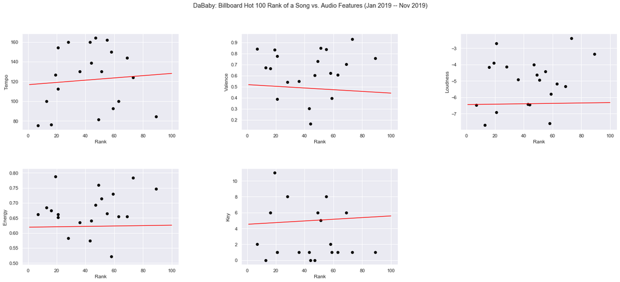

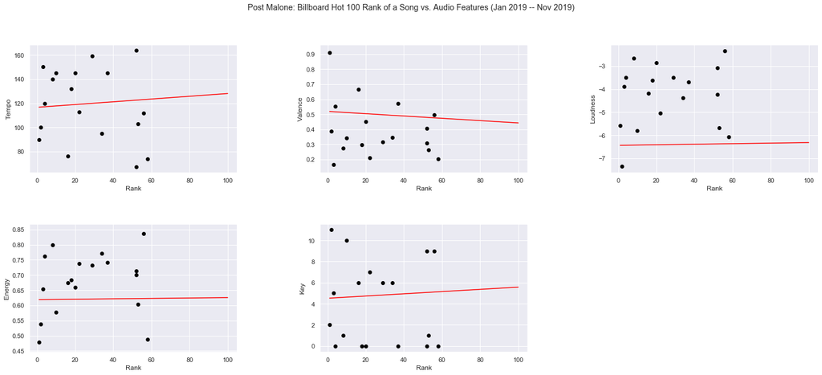

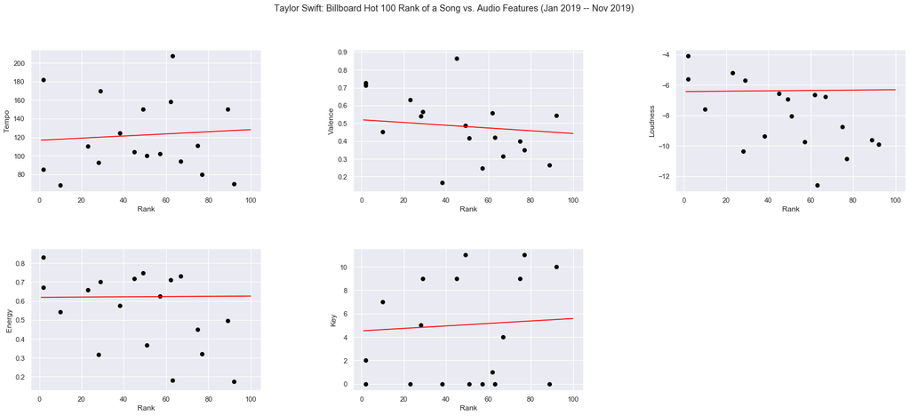

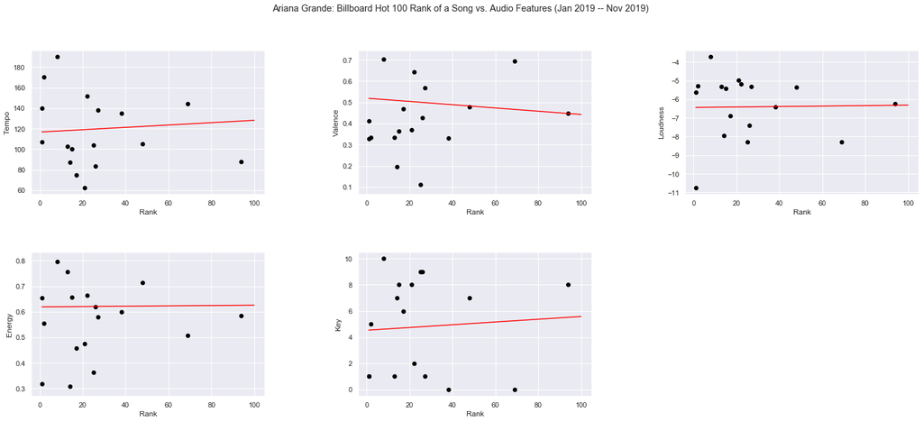

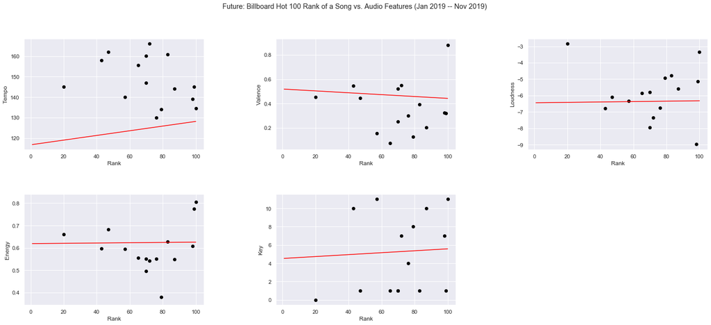

```python
X = unique_songs_df['Rank'].values.reshape(-1,1)
audio_features = ['Tempo', 'Valence', 'Loudness', 'Energy', 'Key']
for artist in selected_artists:
  artist_songs_df = unique_songs_df[unique_songs_df['Artist'].str.contains(artist)]
  fig = plt.figure()
  fig.subplots_adjust(hspace=.4, wspace=.4)
  fig.suptitle(artist + ": Billboard Hot 100 Rank of a Song vs. Audio Features (Jan 2019 -- Nov 2019)\n")
  for i in range(0, len(audio_features)):
    af = audio_features[i]
    y = unique_songs_df[af].values.reshape(-1,1)

    # Create Linear Regression based on plot
    regressor = LinearRegression()
    regressor.fit(X, y)
    ax = fig.add_subplot(2, 3, i+1)
    ax.scatter(artist_songs_df['Rank'], artist_songs_df[af], color = 'black')
    ax.plot(X, regressor.predict(X), color = 'red')
    ax.set_xlabel('Rank')
    ax.set_ylabel(af)
  plt.show()
```

Since the "key" feature has fixed values, why don't we take a look at what keys these artists release most of their hits in?

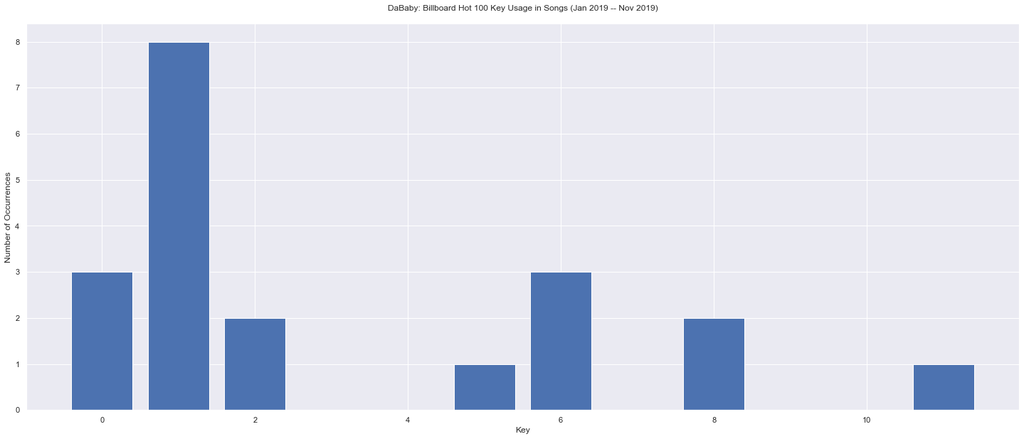

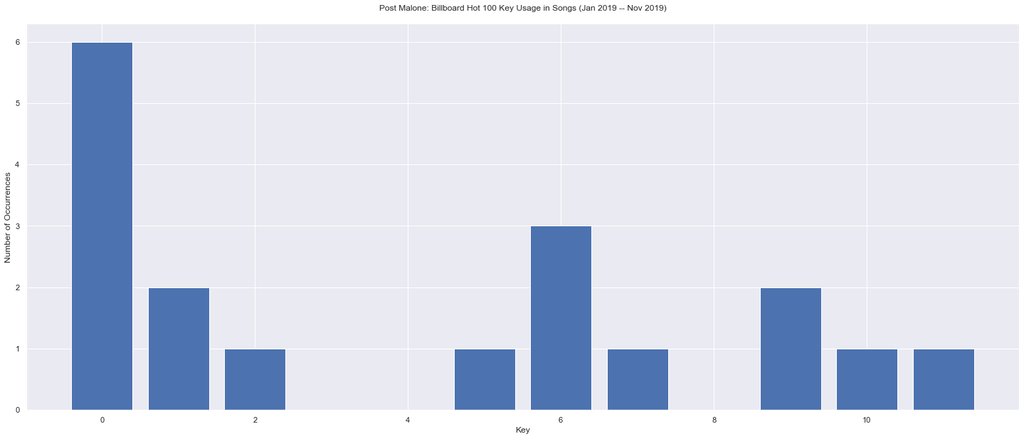

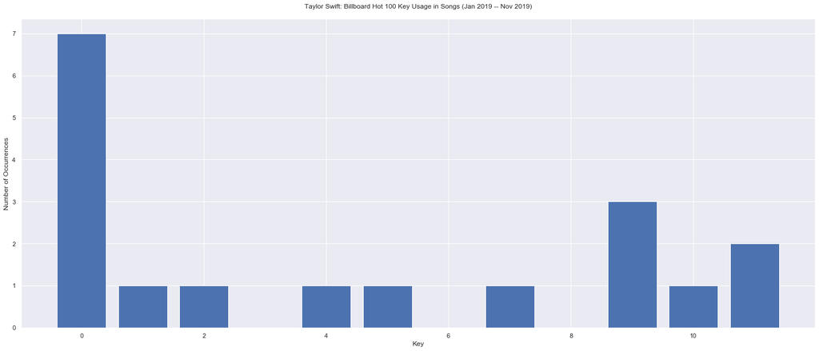

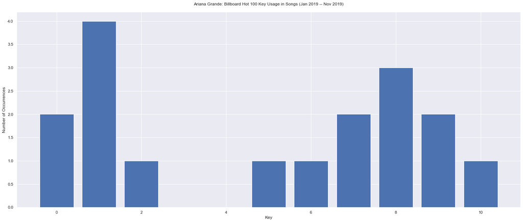

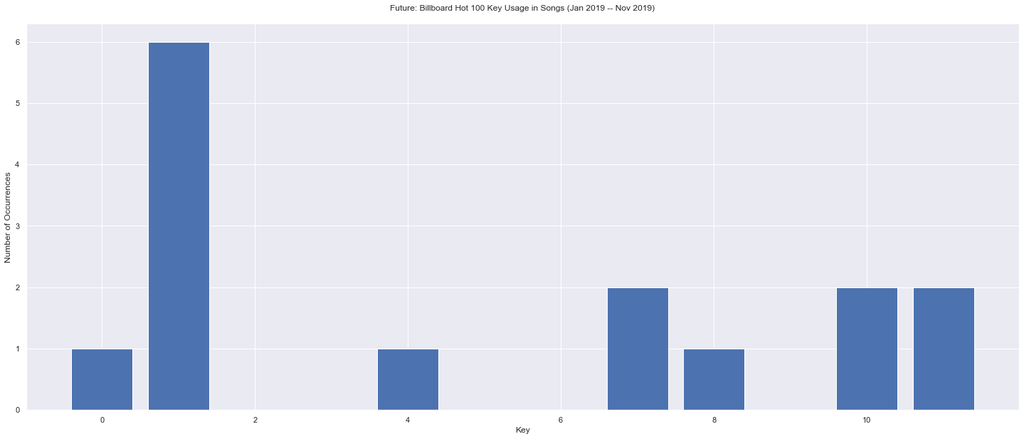

```python
for artist in selected_artists:
  artist_songs_df = unique_songs_df[unique_songs_df['Artist'].str.contains(artist)]
  af = 'Key'
  groupby_key = artist_songs_df.groupby(af)
  names = []
  values = []
  for name, group in groupby_key:
    names.append(name)
    values.append(len(group))

  plt.bar(names, values, align='center')
  plt.title(artist + ": Billboard Hot 100 Key Usage in Songs (Jan 2019 -- Nov 2019)\n")
  plt.xlabel(af)
  plt.ylabel('Number of Occurrences')
  plt.show()
```

# 4. Insights & Conclusions

From our data exploration and analysis, we have unfortunately found out that there is not much correlation between the audio features of a song and how it ranks on the Billboard Hot 100 charts. The graphs of each audio feature vs. rank show a pretty random and even distribution of values, so we cannot conclude anything from the data. However, when we looked at general count of certain audio feature values, we found that there were some values that took the lead.

For musical key, the data showed that C♯/D♭ is by far the most popular key for songs that made it into the Hot 100 charts. In addition, D♯/E♭ turned out to be the least used key among the charting songs. From this, it could go several ways.

- the public is most receptive to songs in C♯/D♭
- people are less likely to like songs in D♯/E♭
- it's easiest to make songs in C♯/D♭
- it's hardest to make songs in D♯/E♭

Without a lot of musical knowledge, it is hard to make conclusions about the last two bullet points. But, we did find a pie chart of all the keys used in Spotify songs:

[figure not shown]

http://thekeyofone.com/blog/the-most-and-least-used-keys-of-music-in-spotify/

This shows us that the most used key is in fact G. C♯ is not even close to being the most used key in all of Spotify. Granted, this chart is from 2016, so there could be changing musical trends, but we believe this is a valid argument that it is not necessarily the easiest to make songs in C♯/D♭.

In order to take into account skewing of data from less popular songs and artists (therefore less telling of general taste), we looked at both the songs that stayed in the Hot 100 chart this year the longest and also the songs of the most popular artists.

Looking at the top 50 songs that stayed in the chart the longest, we see that C♯/D♭ is also the most used key among them and D♯/E♭ and A are least used. We also see that middle to middle-high energy levels, from 0.4 to 0.7, are the most popular. Most of the top 50 had a loudness from -8 to -2.7 dB. There is a preference for songs that are neutral to slightly positive.

# 5. Future Exploration

For future analysis of songs, we would definitely be interested in exploring these same trends over the course of the whole decade--Jan 2010 to December 2019--to see if anything has actually changed musically over time. Additionally, it would be interesting to see if there are any trends in the musical qualities of songs depending on which season they were released in. For example, are winter song releases less energetic than summer releases?

Something we would also like to be able to do is be able to apply some kind of machine learning model to a larger data set to see if we are able to predict a song's Billboard Hot 100 placement based on its sound qualities or its artists' prior performance on the charts. If a successful model could be made, we would also like to see if that could also accurately predict foreign artists' success on the Hot 100, e.g. "Despacito" by Luis Fonsi and Daddy Yankee or "Boy With Luv" by BTS ft. Halsey.